# Report for steneck_gom

## 1. The Data

Here is your dataset as we reprocessed it. Please take a look.

**Click to see the clean data**

```r
#
 study_data |>
          kable( format = "html") %>%
          kable_styling(position = "center", full_width = F, bootstrap_options = c("striped","hover"))%>%
          scroll_box( width = "1000px", height = "500px", fixed_thead = T)
```

| Entry | Study | Region | Site | Depth.m | Sample.Year | Sample.Month | Sample.Day | Latitude | Longitude | Taxon | Fixed.or.Random | Sample.Unit.Size.sq.m | Percent.Cover | Stipe.Density.num.per.sq.m | Individual.Density.num.per.sq.m | Biomass.kg.wet.per.sq.m |
| --- | --- | --- | --- | --- | --- | --- | --- | --- | --- | --- | --- | --- | --- | --- | --- | --- |
| 1 | steneck_gom | NA | Jonesport - browney | 10 | 1996 | 8 | 1 | 44.46390 | -67.62404 | Agarum clathratum | Random | 1 | 30.0000000 | NA | NA | NA |
| 2 | steneck_gom | NA | Jonesport - browney | 10 | 1996 | 8 | 1 | 44.46390 | -67.62404 | Agarum clathratum | Random | 1 | 4.0000000 | NA | NA | NA |
| 3 | steneck_gom | NA | Jonesport - browney | 10 | 1996 | 8 | 1 | 44.46390 | -67.62404 | Agarum clathratum | Random | 1 | 27.0000000 | NA | NA | NA |
| 4 | steneck_gom | NA | Jonesport - browney | 10 | 1996 | 8 | 1 | 44.46390 | -67.62404 | Agarum clathratum | Random | 1 | 22.0000000 | NA | NA | NA |
| 5 | steneck_gom | NA | Jonesport - browney | 10 | 1996 | 8 | 1 | 44.46390 | -67.62404 | Agarum clathratum | Random | 1 | 24.0000000 | NA | NA | NA |
| 6 | steneck_gom | NA | Jonesport - browney | 10 | 1996 | 8 | 1 | 44.46390 | -67.62404 | Agarum clathratum | Random | 1 | 45.0000000 | NA | NA | NA |
| 7 | steneck_gom | NA | Jonesport - browney | 10 | 1996 | 8 | 1 | 44.46390 | -67.62404 | Agarum clathratum | Random | 1 | 14.0000000 | NA | NA | NA |
| 8 | steneck_gom | NA | Jonesport - browney | 10 | 1996 | 8 | 1 | 44.46390 | -67.62404 | Agarum clathratum | Random | 1 | 8.0000000 | NA | NA | NA |
| 9 | steneck_gom | NA | Jonesport - browney | 10 | 1996 | 8 | 1 | 44.46390 | -67.62404 | Agarum clathratum | Random | 1 | 17.0000000 | NA | NA | NA |
| 10 | steneck_gom | NA | Jonesport - browney | 10 | 1996 | 8 | 1 | 44.46390 | -67.62404 | Agarum clathratum | Random | 1 | 21.0000000 | NA | NA | NA |
| 11 | steneck_gom | NA | Jonesport - browney | 10 | 1996 | 8 | 1 | 44.46390 | -67.62404 | Agarum clathratum | Random | 1 | 20.0000000 | NA | NA | NA |
| 12 | steneck_gom | NA | Jonesport - browney | 10 | 1996 | 8 | 1 | 44.46390 | -67.62404 | Agarum clathratum | Random | 1 | 55.0000000 | NA | NA | NA |
| 13 | steneck_gom | NA | Jonesport - browney | 10 | 1996 | 8 | 1 | 44.46390 | -67.62404 | Agarum clathratum | Random | 1 | 25.0000000 | NA | NA | NA |
| 14 | steneck_gom | NA | Jonesport - browney | 10 | 1996 | 8 | 1 | 44.46390 | -67.62404 | Agarum clathratum | Random | 1 | 30.0000000 | NA | NA | NA |
| 15 | steneck_gom | NA | Jonesport - browney | 10 | 1996 | 8 | 1 | 44.46390 | -67.62404 | Agarum clathratum | Random | 1 | 20.0000000 | NA | NA | NA |
| 16 | steneck_gom | NA | Jonesport - browney | 10 | 1996 | 8 | 1 | 44.46390 | -67.62404 | Agarum clathratum | Random | 1 | 40.0000000 | NA | NA | NA |
| 17 | steneck_gom | NA | Jonesport - browney | 10 | 1996 | 8 | 1 | 44.46390 | -67.62404 | Agarum clathratum | Random | 1 | 80.0000000 | NA | NA | NA |
| 18 | steneck_gom | NA | Jonesport - browney | 10 | 1996 | 8 | 1 | 44.46390 | -67.62404 | Agarum clathratum | Random | 1 | 30.0000000 | NA | NA | NA |
| 19 | steneck_gom | NA | Jonesport - browney | 10 | 1996 | 8 | 1 | 44.46390 | -67.62404 | Agarum clathratum | Random | 1 | 25.0000000 | NA | NA | NA |
| 20 | steneck_gom | NA | Jonesport - browney | 10 | 1996 | 8 | 1 | 44.46390 | -67.62404 | Agarum clathratum | Random | 1 | 45.0000000 | NA | NA | NA |
| 21 | steneck_gom | NA | Jonesport - browney | 10 | 1996 | 8 | 1 | 44.46390 | -67.62404 | Agarum clathratum | Random | 1 | 20.0000000 | NA | NA | NA |
| 22 | steneck_gom | NA | Jonesport - browney | 10 | 1996 | 8 | 1 | 44.46390 | -67.62404 | Agarum clathratum | Random | 1 | 25.0000000 | NA | NA | NA |
| 23 | steneck_gom | NA | Jonesport - browney | 10 | 1996 | 8 | 1 | 44.46390 | -67.62404 | Agarum clathratum | Random | 1 | 50.0000000 | NA | NA | NA |
| 24 | steneck_gom | NA | Jonesport - browney | 10 | 1996 | 8 | 1 | 44.46390 | -67.62404 | Agarum clathratum | Random | 1 | 80.0000000 | NA | NA | NA |
| 25 | steneck_gom | NA | Jonesport - browney | 10 | 1996 | 8 | 1 | 44.46390 | -67.62404 | Agarum clathratum | Random | 1 | 90.0000000 | NA | NA | NA |
| 26 | steneck_gom | NA | Jonesport - browney | 10 | 1996 | 8 | 1 | 44.46390 | -67.62404 | Agarum clathratum | Random | 1 | 50.0000000 | NA | NA | NA |
| 27 | steneck_gom | NA | Jonesport - browney | 10 | 1996 | 8 | 1 | 44.46390 | -67.62404 | Agarum clathratum | Random | 1 | 50.0000000 | NA | NA | NA |
| 28 | steneck_gom | NA | Jonesport - browney | 10 | 1996 | 8 | 1 | 44.46390 | -67.62404 | Agarum clathratum | Random | 1 | 0.0000000 | NA | NA | NA |
| 29 | steneck_gom | NA | Jonesport - browney | 10 | 1996 | 8 | 1 | 44.46390 | -67.62404 | Agarum clathratum | Random | 1 | 30.0000000 | NA | NA | NA |
| 30 | steneck_gom | NA | Jonesport - browney | 10 | 1996 | 8 | 1 | 44.46390 | -67.62404 | Agarum clathratum | Random | 1 | 40.0000000 | NA | NA | NA |

[output cut: 12438 more lines]

Here is your dataset as where we have now summed across all kelp species and put into the KelpTime main database format.

**Click to see the data in kelptime format**

```r
#|
kelptime_study |>
         kable( format = "html") %>%
         kable_styling(position = "center", full_width = F, bootstrap_options = c("striped","hover"))%>%
         scroll_box( width = "1000px", height = "500px", fixed_thead = T)
```

| study | site | period | latitude | longitude | sample_unit_size_sq_m | sasdate | max_depth | mean_depth | min_depth | biomass_kg_wet_per_sq_m | stipe_density_num_per_sq_m | individual_density_num_per_sq_m | percent_cover | has_bm | has_sd | has_id | has_pc | use_which | focalKelp | focalUnit | geometry | ecoregion | province | realm | focal_std_by_ecoregion | focal_std_by_province | focal_std_by_realm | ln_focal_std_by_ecoregion | ln_focal_std_by_province | … |
| --- | --- | --- | --- | --- | --- | --- | --- | --- | --- | --- | --- | --- | --- | --- | --- | --- | --- | --- | --- | --- | --- | --- | --- | --- | --- | --- | --- | --- | --- | --- |
| steneck_gom | Jonesport - browney | 1 | 44.46390 | -67.62404 | 1 | 1996-08-01 | 10 | 10 | 10 | NA | NA | NA | 34.1346154 | 0 | 0 | 0 | 101 | 4 | 34.1346154 | Percent cover | c(-67.624035, 44.463898) | Gulf of Maine/Bay of Fundy | Cold Temperate Northwest Atlantic | Temperate Northern Atlantic | 0.3413462 | 0.1369668 | 0.1369668 | -1.0459833 | -1.917548 | … |
| steneck_gom | Jonesport - browney | 2 | 44.46390 | -67.62404 | 1 | 1997-08-01 | 10 | 10 | 10 | NA | NA | NA | 27.7352941 | 0 | 0 | 0 | 101 | 4 | 27.7352941 | Percent cover | c(-67.624035, 44.463898) | Gulf of Maine/Bay of Fundy | Cold Temperate Northwest Atlantic | Temperate Northern Atlantic | 0.2773529 | 0.1112892 | 0.1112892 | -1.2470441 | -2.109577 | … |
| steneck_gom | Jonesport - little drisco | 1 | 44.48333 | -67.66333 | 1 | 1999-08-01 | 10 | 10 | 10 | NA | NA | NA | 28.5000000 | 0 | 0 | 0 | 101 | 4 | 28.5000000 | Percent cover | c(-67.6633333, 44.4833333) | Gulf of Maine/Bay of Fundy | Cold Temperate Northwest Atlantic | Temperate Northern Atlantic | 0.2850000 | 0.1143577 | 0.1143577 | -1.2207799 | -2.084593 | … |
| steneck_gom | Jonesport - little drisco | 2 | 44.48333 | -67.66333 | 1 | 2000-08-01 | 10 | 10 | 10 | NA | NA | NA | 26.7500000 | 0 | 0 | 0 | 101 | 4 | 26.7500000 | Percent cover | c(-67.6633333, 44.4833333) | Gulf of Maine/Bay of Fundy | Cold Temperate Northwest Atlantic | Temperate Northern Atlantic | 0.2675000 | 0.1073357 | 0.1073357 | -1.2819343 | -2.142716 | … |
| steneck_gom | Jonesport - little drisco | 3 | 44.48333 | -67.66333 | 1 | 2001-08-01 | 10 | 10 | 10 | NA | NA | NA | 49.4333333 | 0 | 0 | 0 | 101 | 4 | 49.4333333 | Percent cover | c(-67.6633333, 44.4833333) | Gulf of Maine/Bay of Fundy | Cold Temperate Northwest Atlantic | Temperate Northern Atlantic | 0.4943333 | 0.1983537 | 0.1983537 | -0.6845179 | -1.568518 | … |
| steneck_gom | Jonesport - little drisco | 4 | 44.48333 | -67.66333 | 1 | 2002-08-01 | 10 | 10 | 10 | NA | NA | NA | 46.1250000 | 0 | 0 | 0 | 101 | 4 | 46.1250000 | Percent cover | c(-67.6633333, 44.4833333) | Gulf of Maine/Bay of Fundy | Cold Temperate Northwest Atlantic | Temperate Northern Atlantic | 0.4612500 | 0.1850788 | 0.1850788 | -0.7523665 | -1.634351 | … |
| steneck_gom | Jonesport - little drisco | 5 | 44.48333 | -67.66333 | 1 | 2003-08-01 | 10 | 10 | 10 | NA | NA | NA | 32.9310345 | 0 | 0 | 0 | 101 | 4 | 32.9310345 | Percent cover | c(-67.6633333, 44.4833333) | Gulf of Maine/Bay of Fundy | Cold Temperate Northwest Atlantic | Temperate Northern Atlantic | 0.3293103 | 0.1321374 | 0.1321374 | -1.0808401 | -1.950961 | … |
| steneck_gom | Jonesport - outer ram | 1 | 44.49167 | -67.63667 | 1 | 1996-08-01 | 10 | 10 | 10 | NA | NA | NA | 0.0000000 | 0 | 0 | 0 | 101 | 4 | 0.0000000 | Percent cover | c(-67.6366667, 44.4916667) | Gulf of Maine/Bay of Fundy | Cold Temperate Northwest Atlantic | Temperate Northern Atlantic | 0.0000000 | 0.0000000 | 0.0000000 | -4.6051702 | -4.605170 | … |
| steneck_gom | Jonesport - outer ram | 2 | 44.49167 | -67.63667 | 1 | 1999-08-01 | 10 | 10 | 10 | NA | NA | NA | 0.0000000 | 0 | 0 | 0 | 101 | 4 | 0.0000000 | Percent cover | c(-67.6366667, 44.4916667) | Gulf of Maine/Bay of Fundy | Cold Temperate Northwest Atlantic | Temperate Northern Atlantic | 0.0000000 | 0.0000000 | 0.0000000 | -4.6051702 | -4.605170 | … |
| steneck_gom | Jonesport - outer ram | 3 | 44.49167 | -67.63667 | 1 | 2000-08-01 | 10 | 10 | 10 | NA | NA | NA | 0.0000000 | 0 | 0 | 0 | 101 | 4 | 0.0000000 | Percent cover | c(-67.6366667, 44.4916667) | Gulf of Maine/Bay of Fundy | Cold Temperate Northwest Atlantic | Temperate Northern Atlantic | 0.0000000 | 0.0000000 | 0.0000000 | -4.6051702 | -4.605170 | … |
| steneck_gom | Jonesport - outer ram | 4 | 44.49167 | -67.63667 | 1 | 2001-08-01 | 10 | 10 | 10 | NA | NA | NA | 0.0000000 | 0 | 0 | 0 | 101 | 4 | 0.0000000 | Percent cover | c(-67.6366667, 44.4916667) | Gulf of Maine/Bay of Fundy | Cold Temperate Northwest Atlantic | Temperate Northern Atlantic | 0.0000000 | 0.0000000 | 0.0000000 | -4.6051702 | -4.605170 | … |
| steneck_gom | Jonesport - outer ram | 5 | 44.49167 | -67.63667 | 1 | 2002-08-01 | 10 | 10 | 10 | NA | NA | NA | 0.0000000 | 0 | 0 | 0 | 101 | 4 | 0.0000000 | Percent cover | c(-67.6366667, 44.4916667) | Gulf of Maine/Bay of Fundy | Cold Temperate Northwest Atlantic | Temperate Northern Atlantic | 0.0000000 | 0.0000000 | 0.0000000 | -4.6051702 | -4.605170 | … |
| steneck_gom | Jonesport - outer ram | 6 | 44.49167 | -67.63667 | 1 | 2003-08-01 | 10 | 10 | 10 | NA | NA | NA | 0.0714286 | 0 | 0 | 0 | 101 | 4 | 0.0714286 | Percent cover | c(-67.6366667, 44.4916667) | Gulf of Maine/Bay of Fundy | Cold Temperate Northwest Atlantic | Temperate Northern Atlantic | 0.0007143 | 0.0002866 | 0.0002866 | -4.5361773 | -4.576912 | … |
| steneck_gom | Jonesport - outer sand | 1 | 44.46167 | -67.67833 | 1 | 1996-08-01 | 10 | 10 | 10 | NA | NA | NA | 2.9365079 | 0 | 0 | 0 | 101 | 4 | 2.9365079 | Percent cover | c(-67.6783333, 44.4616667) | Gulf of Maine/Bay of Fundy | Cold Temperate Northwest Atlantic | Temperate Northern Atlantic | 0.0293651 | 0.0117829 | 0.0117829 | -3.2348762 | -3.826631 | … |
| steneck_gom | Jonesport - outer sand | 2 | 44.46167 | -67.67833 | 1 | 1997-08-01 | 10 | 10 | 10 | NA | NA | NA | 3.7837838 | 0 | 0 | 0 | 101 | 4 | 3.7837838 | Percent cover | c(-67.6783333, 44.4616667) | Gulf of Maine/Bay of Fundy | Cold Temperate Northwest Atlantic | Temperate Northern Atlantic | 0.0378378 | 0.0151826 | 0.0151826 | -3.0399384 | -3.681601 | … |
| steneck_gom | Jonesport - ram | 1 | 44.49167 | -67.63500 | 1 | 1997-08-01 | 10 | 10 | 10 | NA | NA | NA | 0.0000000 | 0 | 0 | 0 | 101 | 4 | 0.0000000 | Percent cover | c(-67.635, 44.4916667) | Gulf of Maine/Bay of Fundy | Cold Temperate Northwest Atlantic | Temperate Northern Atlantic | 0.0000000 | 0.0000000 | 0.0000000 | -4.6051702 | -4.605170 | … |
| steneck_gom | Jonesport - ram | 2 | 44.49167 | -67.63500 | 1 | 1998-08-01 | 10 | 10 | 10 | NA | NA | NA | 0.0000000 | 0 | 0 | 0 | 101 | 4 | 0.0000000 | Percent cover | c(-67.635, 44.4916667) | Gulf of Maine/Bay of Fundy | Cold Temperate Northwest Atlantic | Temperate Northern Atlantic | 0.0000000 | 0.0000000 | 0.0000000 | -4.6051702 | -4.605170 | … |
| steneck_gom | Jonesport - ram | 3 | 44.49167 | -67.63500 | 1 | 1999-08-01 | 10 | 10 | 10 | NA | NA | NA | 2.0967742 | 0 | 0 | 0 | 101 | 4 | 2.0967742 | Percent cover | c(-67.635, 44.4916667) | Gulf of Maine/Bay of Fundy | Cold Temperate Northwest Atlantic | Temperate Northern Atlantic | 0.0209677 | 0.0084134 | 0.0084134 | -3.4748092 | -3.994676 | … |
| steneck_gom | Jonesport - ram | 4 | 44.49167 | -67.63500 | 1 | 2000-08-01 | 10 | 10 | 10 | NA | NA | NA | 0.6774194 | 0 | 0 | 0 | 101 | 4 | 0.6774194 | Percent cover | c(-67.635, 44.4916667) | Gulf of Maine/Bay of Fundy | Cold Temperate Northwest Atlantic | Temperate Northern Atlantic | 0.0067742 | 0.0027182 | 0.0027182 | -4.0879137 | -4.364723 | … |
| steneck_gom | Jonesport - ram | 5 | 44.49167 | -67.63500 | 1 | 2001-08-01 | 10 | 10 | 10 | NA | NA | NA | 1.6666667 | 0 | 0 | 0 | 101 | 4 | 1.6666667 | Percent cover | c(-67.635, 44.4916667) | Gulf of Maine/Bay of Fundy | Cold Temperate Northwest Atlantic | Temperate Northern Atlantic | 0.0166667 | 0.0066876 | 0.0066876 | -3.6243409 | -4.093090 | … |
| steneck_gom | Jonesport - ram | 6 | 44.49167 | -67.63500 | 1 | 2002-08-01 | 10 | 10 | 10 | NA | NA | NA | 1.9000000 | 0 | 0 | 0 | 101 | 4 | 1.9000000 | Percent cover | c(-67.635, 44.4916667) | Gulf of Maine/Bay of Fundy | Cold Temperate Northwest Atlantic | Temperate Northern Atlantic | 0.0190000 | 0.0076238 | 0.0076238 | -3.5404594 | -4.038502 | … |
| steneck_gom | Jonesport - ram | 7 | 44.49167 | -67.63500 | 1 | 2003-08-01 | 10 | 10 | 10 | NA | NA | NA | 5.8000000 | 0 | 0 | 0 | 101 | 4 | 5.8000000 | Percent cover | c(-67.635, 44.4916667) | Gulf of Maine/Bay of Fundy | Cold Temperate Northwest Atlantic | Temperate Northern Atlantic | 0.0580000 | 0.0232728 | 0.0232728 | -2.6882476 | -3.403015 | … |
| steneck_gom | Jonesport - sea duck | 1 | 44.49152 | -67.65292 | 1 | 1996-08-01 | 10 | 10 | 10 | NA | NA | NA | 55.1363636 | 0 | 0 | 0 | 101 | 4 | 55.1363636 | Percent cover | c(-67.65292, 44.491517) | Gulf of Maine/Bay of Fundy | Cold Temperate Northwest Atlantic | Temperate Northern Atlantic | 0.5513636 | 0.2212374 | 0.2212374 | -0.5773864 | -1.464310 | … |
| steneck_gom | Jonesport - sea duck | 2 | 44.49152 | -67.65292 | 1 | 1997-08-01 | 10 | 10 | 10 | NA | NA | NA | 60.3421053 | 0 | 0 | 0 | 101 | 4 | 60.3421053 | Percent cover | c(-67.65292, 44.491517) | Gulf of Maine/Bay of Fundy | Cold Temperate Northwest Atlantic | Temperate Northern Atlantic | 0.6034211 | 0.2421257 | 0.2421257 | -0.4887037 | -1.377828 | … |
| steneck_gom | Jonesport - sea duck | 3 | 44.49152 | -67.65292 | 1 | 1998-08-01 | 10 | 10 | 10 | NA | NA | NA | 24.6000000 | 0 | 0 | 0 | 101 | 4 | 24.6000000 | Percent cover | c(-67.65292, 44.491517) | Gulf of Maine/Bay of Fundy | Cold Temperate Northwest Atlantic | Temperate Northern Atlantic | 0.2460000 | 0.0987087 | 0.0987087 | -1.3625778 | -2.219083 | … |
| steneck_gom | Jonesport - sea duck | 4 | 44.49152 | -67.65292 | 1 | 1999-08-01 | 10 | 10 | 10 | NA | NA | NA | 37.0625000 | 0 | 0 | 0 | 101 | 4 | 37.0625000 | Percent cover | c(-67.65292, 44.491517) | Gulf of Maine/Bay of Fundy | Cold Temperate Northwest Atlantic | Temperate Northern Atlantic | 0.3706250 | 0.1487151 | 0.1487151 | -0.9659406 | -1.840644 | … |
| steneck_gom | Jonesport - sea duck | 5 | 44.49152 | -67.65292 | 1 | 2000-08-01 | 10 | 10 | 10 | NA | NA | NA | 44.7941176 | 0 | 0 | 0 | 101 | 4 | 44.7941176 | Percent cover | c(-67.65292, 44.491517) | Gulf of Maine/Bay of Fundy | Cold Temperate Northwest Atlantic | Temperate Northern Atlantic | 0.4479412 | 0.1797386 | 0.1797386 | -0.7810145 | -1.662108 | … |
| steneck_gom | Jonesport - sea duck | 6 | 44.49152 | -67.65292 | 1 | 2001-08-01 | 10 | 10 | 10 | NA | NA | NA | 57.8620690 | 0 | 0 | 0 | 101 | 4 | 57.8620690 | Percent cover | c(-67.65292, 44.491517) | Gulf of Maine/Bay of Fundy | Cold Temperate Northwest Atlantic | Temperate Northern Atlantic | 0.5786207 | 0.2321744 | 0.2321744 | -0.5299733 | -1.418097 | … |
| steneck_gom | Jonesport - sea duck | 7 | 44.49152 | -67.65292 | 1 | 2002-08-01 | 10 | 10 | 10 | NA | NA | NA | 30.8333333 | 0 | 0 | 0 | 101 | 4 | 30.8333333 | Percent cover | c(-67.65292, 44.491517) | Gulf of Maine/Bay of Fundy | Cold Temperate Northwest Atlantic | Temperate Northern Atlantic | 0.3083333 | 0.1237203 | 0.1237203 | -1.1446562 | -2.012005 | … |
| steneck_gom | Jonesport - sea duck | 8 | 44.49152 | -67.65292 | 1 | 2003-08-01 | 10 | 10 | 10 | NA | NA | NA | 38.0909091 | 0 | 0 | 0 | 101 | 4 | 38.0909091 | Percent cover | c(-67.65292, 44.491517) | Gulf of Maine/Bay of Fundy | Cold Temperate Northwest Atlantic | Temperate Northern Atlantic | 0.3809091 | 0.1528417 | 0.1528417 | -0.9392803 | -1.814977 | … |

[output cut: 71 more lines]

## 2. Plots of raw data

### 2.1 By metric

Here is what your data looks like with all sites plotted together looking at each sampling metric.

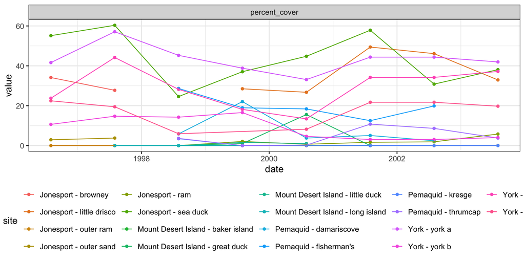

```r
kelptime_study_measurement_long <-
  kelptime_study |>
  tidyr::pivot_longer(cols =biomass_kg_wet_per_sq_m:percent_cover) |>
  filter(!is.na(value))

ggplot(kelptime_study_measurement_long,
       aes(x = date, y = value,
           color = site)) +
  geom_point() +
  geom_line() +
  facet_wrap(vars(name), scale = "free_y")
```

### 2.2 Standardized data

Here is what your data looks like with all sites plotted together where we take the preferred metric (order of preference: biomass, percent cover, individual count) and standardize it by dividing it by the highest value in the Ecoregion.

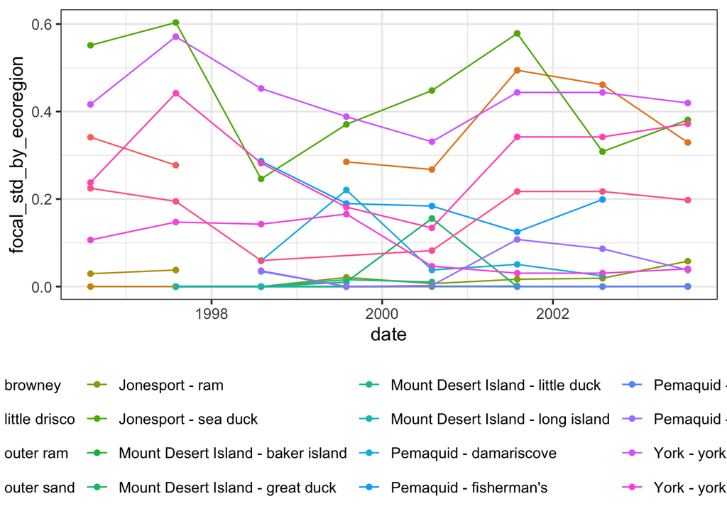

```r
ggplot(kelptime_study,
       aes(x = date, y = focal_std_by_ecoregion,
           color = site)) +
  geom_point() +
  geom_line()
```

### 2.3 Standardized data by site

Here is what your data looks like with all sites plotted together where we take the preferred metric (order of preference: biomass, percent cover, individual count) and standardize it by dividing it by the highest value in the Ecoregion. We then facet by site so that you can look at each site indivudally to assess if trends look accurate.

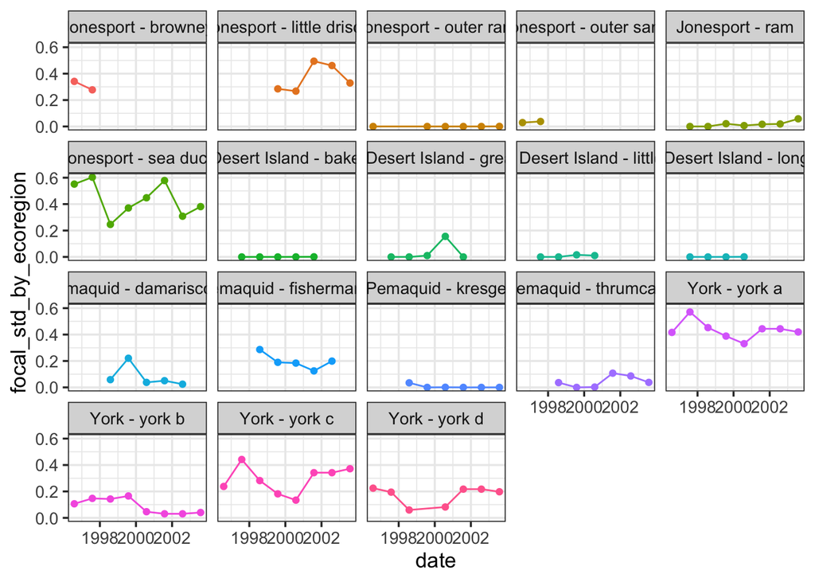

```r
ggplot(kelptime_study,
       aes(x = date, y = focal_std_by_ecoregion,
           color = site)) +
  geom_point() +
  geom_line() +
  facet_wrap(vars(site)) +
  guides(color = "none")
```

## 3. Modeled timeseries resuls

We fit two models. One where the slope varies by ecoregion (note: the GOSL and Newfoundland are collapsed) and one where the slope does not vary by ecoregion. Based on the modeled results, here is the smoothed fits to your data. Note - thus far, the model with a common slope appears to be the correct is the one with a common slope (best fit in terms of prediction and p-value for slope*ecoregion is not distinguishable from 0).

**Note** - the study (black) line might not line up in the middle or on trajectories, as it is shrunken in towards the grand mean for the ecoregion.

### 3.1 Slope Varying by Ecoregion Model

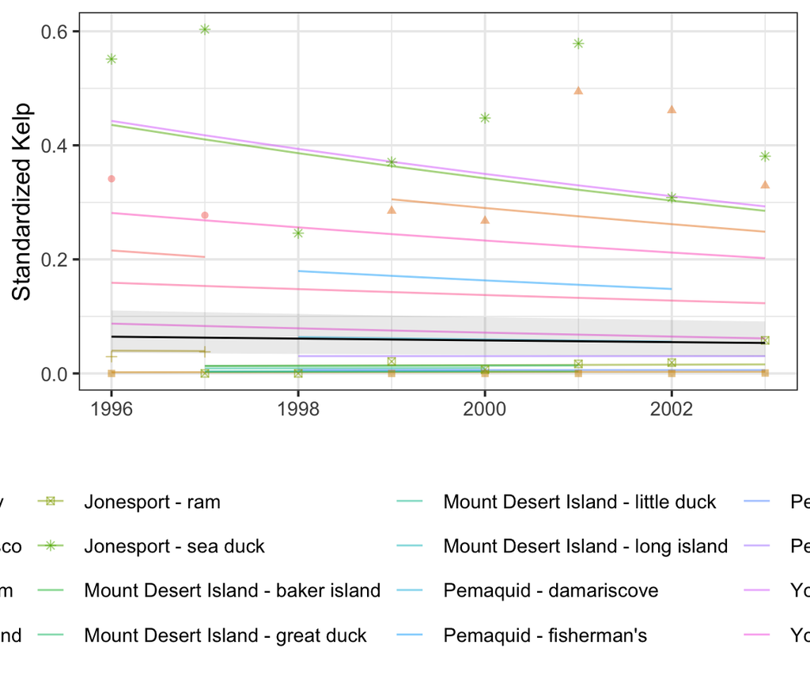

```r
mod_ecoregion <- readRDS("models/mod_ecoregion.rds")


# for plotting to do the back transform
exp_trans <- function(dat){

  dat |>
    mutate(
      Predicted = exp(Predicted)-0.01,
           CI_low = exp(CI_low)-0.01,
           CI_high = exp(CI_high)-0.01,
           CI_high = ifelse(CI_high>1.1, 1.1, CI_high)
    )|>
               mutate(trajectory =
                        gsub(study[1], "", trajectory))

}


re_ecoregion <- ranef(mod_ecoregion)$cond$study |>
  as_tibble(rownames = "study")  |>
  filter(study == params$study) |>
  pull(`(Intercept)`)


dat_fixed_ecoregion <- estimate_relation(mod_ecoregion,
                               include_random = FALSE,
                  length = 200,
                  data = kelptime_study) |>
  mutate(Predicted = Predicted + re_ecoregion,
         CI_high = CI_high + re_ecoregion,
         CI_low = CI_low + re_ecoregion) |>
  exp_trans()

dat_traj_ecoregion <- estimate_relation(mod_ecoregion,
                              include_random = TRUE,
                  length = 200,
                  data = kelptime_study) |>
    exp_trans()


ggplot(dat_traj_ecoregion, aes(x = year)) +
  geom_line(aes(y = Predicted,
                color = trajectory), alpha = 0.5) +
  geom_point(aes(y = focal_std_by_ecoregion,
                 group = trajectory,
                 shape = trajectory,
                 color = trajectory), alpha = 0.5,
             data = kelptime_study |>
               mutate(trajectory =
                        gsub(study[1], "", trajectory))) +
  geom_line(data = dat_fixed_ecoregion,
            aes(y = Predicted), color = "black") +
  geom_ribbon(data = dat_fixed_ecoregion,
            aes(y = Predicted,
                ymin = CI_low,
                ymax = CI_high), color = NA,
            alpha = 0.1) +
  labs(x = "", y = "Standardized Kelp",
      color = "site", shape = "site")
```

### 3.2 Common Slope Model

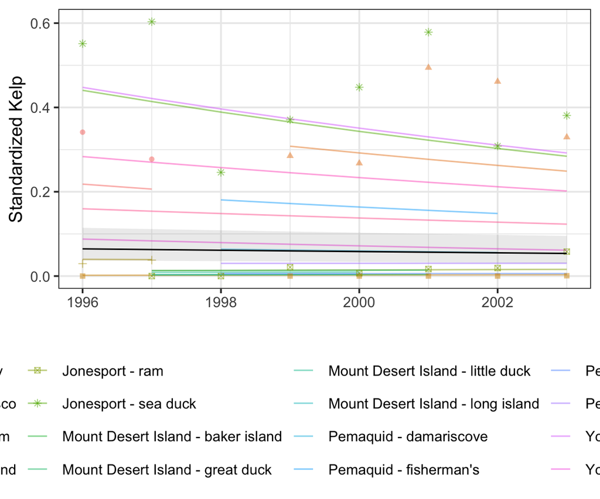

```r
mod_common_slope <- readRDS("models/mod_common_slope.rds")

re <- ranef(mod_common_slope)$cond$study |>
  as_tibble(rownames = "study")  |>
  filter(study == params$study) |>
  pull(`(Intercept)`)


dat_fixed <- estimate_relation(mod_common_slope,
                               include_random = FALSE,
                  length = 200,
                  data = kelptime_study) |>
  mutate(Predicted = Predicted + re,
         CI_high = CI_high + re_ecoregion,
         CI_low = CI_low + re_ecoregion) |>
  exp_trans()

dat_traj <- estimate_relation(mod_common_slope,
                              include_random = TRUE,
                  length = 200,
                  data = kelptime_study) |>
    exp_trans()

ggplot(dat_traj, aes(x = year)) +
  geom_line(aes(y = Predicted,
                color = trajectory), alpha = 0.5) +
  geom_point(aes(y = focal_std_by_ecoregion,
                 group = trajectory,
                 shape = trajectory,
                 color = trajectory), alpha = 0.5,
             data = kelptime_study |>
               mutate(trajectory =
                        gsub(study[1], "", trajectory))) +
  geom_line(data = dat_fixed,
            aes(y = Predicted), color = "black") +
  geom_ribbon(data = dat_fixed,
            aes(y = Predicted,
                ymin = CI_low,
                ymax = CI_high), color = NA,
            alpha = 0.1) +
  labs(x = "", y = "Standardized Kelp",
      color = "site", shape = "site")
```